# IPI

# 1 Load required packages

```r
library("tidyr")
library("dplyr")
library("stringr")
library("car")
```

```r
library("visreg")
library("optimx")
library("ggplot2")
library("optimx")
library("mgcv")
library("itsadug")
library("car")
```

# 2 Introduction

From the c-center hypothesis it follows that onsets are coordinated inphase with the following vowel, meaning that they are initiated roughly around the same time. On the other hand, multiple consonants in an onset are also coordinated antiphase with each other (i.e. sequential initiation). To cope with these competing relations, the leftmost C gets shifted towards the left and the rightmost C gets shifted towards the right (with respect to the following vowel) in complex onsets. In this way, the average onset of the two C’s is still initiated at the same time as the vowel, whereas they are also still coordinated in an antiphase relation with each other. Our hypothesis is that PD patients will show a stronger preference for the inphase relationship, coming at the cost of the antiphase relationship. In our data we’ve included three singular onsets /p/, /m/ and /x/ and four complex onsets: /sp/, /sm/, /sx/ and /spr/. The variable ‘time.lag.norm’ is the normalized time lag between the offset of the leftmost C and the onset of the rightmost C. If our hypothesis is correct the lag between the C’s should be lower for the PD group in comparison with the controls.

## 2.1 Read data

```r
df <- readRDS("../data/modelling_data_CC.rds")
```

## 2.2 Clean data

Remove all the rows that have NA in the dependent variable and drop ‘empty’ levels, convert variables to factors and create trimmed dataset.

```r
df$subj <- as.factor(df$subj)

df <- df[complete.cases(df$time.lag.norm),]
df <- droplevels(df)

# Sort data
df <- df[order(df$subj, df$recording.no),]

# convert to factors/numeric
df$prompt <- as.factor(df$prompt)
df$condition <- as.factor(df$condition)

# remove all the recordings without a speech rate measure:
# df <- df %>% drop_na(duration.tt)

# remove participants with only a few datapoints
#remove <- c("PD19", "CTRL19")
#df.trim <- df[! df$subj %in% remove, ]
#df.trim <- droplevels(df.trim)


# create df without sx
#df.trim <- df.trim[! df.trim$cluster == "sx", ]
#df.trim <- droplevels(df.trim)
#levels(df.trim$cluster)

# create df without spr
df.nospr <- df[! df$cluster == "spr", ]
df.nospr <- droplevels(df.nospr)
levels(df.nospr$cluster)
```

```
## [1] "sm" "sp" "sx"
```

```r
df.nospr$cluster <- relevel(df.nospr$cluster, ref = "sm")



# merge /sm/ and /sp/
df.nospr$poa <- ifelse(df.nospr$cluster == "sx","C2lingual","C2bilabial")
df.nospr$poa <- as.factor(df.nospr$poa)
table(df.nospr$poa, df.nospr$cluster)
```

```
##
##               sm  sp  sx
##   C2bilabial 406 432   0
##   C2lingual    0   0 300
```

# 3 GAM models for CC lag analysis (coarticulation)

If indeed patients would show a stronger preference for inphase coordination, this would mean that they would produce the C gestures in the syllable’s onset closer together in time. For this, we look at the lag between the gestural offset of the leftmost C and the gestural onset of the righmost C in complex clusters.

## 3.1 Hypothesis testing

Fitting first model, smooth over subject:

```r
summary(m <- bam(time.lag.norm ~ s(subj, bs='re'), data=df.nospr, method = "ML"))
```

```
##
## Family: gaussian
## Link function: identity
##
## Formula:
## time.lag.norm ~ s(subj, bs = "re")
##
## Parametric coefficients:
##             Estimate Std. Error t value Pr(>|t|)
## (Intercept) 0.047829   0.001927   24.82   <2e-16 ***
## ---
## Signif. codes:  0 '***' 0.001 '**' 0.01 '*' 0.05 '.' 0.1 ' ' 1
##
## Approximate significance of smooth terms:
##           edf Ref.df     F p-value
## s(subj) 33.87     46 3.067  <2e-16 ***
## ---
## Signif. codes:  0 '***' 0.001 '**' 0.01 '*' 0.05 '.' 0.1 ' ' 1
##
## R-sq.(adj) =  0.111   Deviance explained = 13.7%
## -ML = -2264.9  Scale est. = 0.0010337  n = 1138
```

Adding group as fixed effect:

```r
summary(m1 <- bam(time.lag.norm ~ s(subj,bs='re') + group, data=df.nospr, method = "ML"))
```

```
##
## Family: gaussian
## Link function: identity
##
## Formula:
## time.lag.norm ~ s(subj, bs = "re") + group
##
## Parametric coefficients:
##             Estimate Std. Error t value Pr(>|t|)
## (Intercept) 0.046172   0.002651  17.416   <2e-16 ***
## groupPD     0.003441   0.003816   0.902    0.367
## ---
## Signif. codes:  0 '***' 0.001 '**' 0.01 '*' 0.05 '.' 0.1 ' ' 1
##
## Approximate significance of smooth terms:
##           edf Ref.df    F p-value
## s(subj) 32.88     45 3.04  <2e-16 ***
## ---
## Signif. codes:  0 '***' 0.001 '**' 0.01 '*' 0.05 '.' 0.1 ' ' 1
##
## R-sq.(adj) =  0.111   Deviance explained = 13.7%
## -ML = -2265.3  Scale est. = 0.0010341  n = 1138
```

```r
compareML(m,m1)
```

```
## m: time.lag.norm ~ s(subj, bs = "re")
##
## m1: time.lag.norm ~ s(subj, bs = "re") + group
```

```
##
## Chi-square test of ML scores
## -----
##   Model     Score Edf Difference    Df p.value Sig.
## 1     m -2264.913   2
## 2    m1 -2265.315   3      0.401 1.000   0.370
##
## AIC difference: -0.51, model m has lower AIC.
```

Fit final model

```r
summary(m1.REML <- bam(time.lag.norm ~ s(subj,bs='re') + group, data=df.nospr, method = "REML"))
```

```
##
## Family: gaussian
## Link function: identity
##
## Formula:
## time.lag.norm ~ s(subj, bs = "re") + group
##
## Parametric coefficients:
##             Estimate Std. Error t value Pr(>|t|)
## (Intercept) 0.046173   0.002710  17.036   <2e-16 ***
## groupPD     0.003424   0.003901   0.878     0.38
## ---
## Signif. codes:  0 '***' 0.001 '**' 0.01 '*' 0.05 '.' 0.1 ' ' 1
##
## Approximate significance of smooth terms:
##           edf Ref.df     F p-value
## s(subj) 33.38     45 3.086  <2e-16 ***
## ---
## Signif. codes:  0 '***' 0.001 '**' 0.01 '*' 0.05 '.' 0.1 ' ' 1
##
## R-sq.(adj) =  0.111   Deviance explained = 13.8%
## -REML = -2255.3  Scale est. = 0.0010336  n = 1138
```

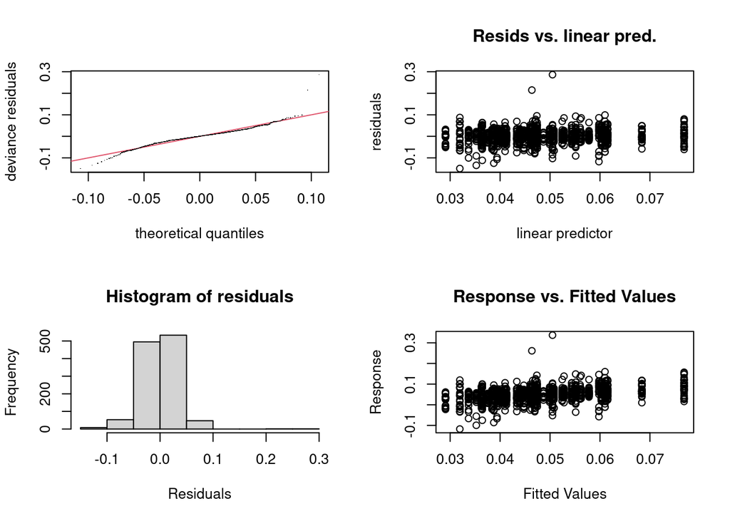

```
##
## Method: ML   Optimizer: outer newton
## full convergence after 5 iterations.
## Gradient range [-5.533468e-08,2.56567e-09]
## (score -2265.315 & scale 0.00103408).
## Hessian positive definite, eigenvalue range [12.13786,569.5301].
## Model rank =  49 / 49
##
## Basis dimension (k) checking results. Low p-value (k-index<1) may
## indicate that k is too low, especially if edf is close to k'.
##
##           k'  edf k-index p-value
## s(subj) 47.0 32.9      NA      NA
```

```r
gam.check(m1)
```

```r
summary(m1.scat <- bam(time.lag.norm ~ s(subj,bs='re') + group, data=df.nospr, method = "fREML", family = "scat", discrete = T))
```

```
##
## Family: Scaled t(3.102,0.02)
## Link function: identity
##
## Formula:
## time.lag.norm ~ s(subj, bs = "re") + group
##
## Parametric coefficients:
##             Estimate Std. Error t value Pr(>|t|)
## (Intercept) 0.048083   0.002672  17.994   <2e-16 ***
## groupPD     0.001410   0.003826   0.368    0.713
## ---
## Signif. codes:  0 '***' 0.001 '**' 0.01 '*' 0.05 '.' 0.1 ' ' 1
##
## Approximate significance of smooth terms:
##           edf Ref.df    F p-value
## s(subj) 36.95     45 1297 0.00218 **
## ---
## Signif. codes:  0 '***' 0.001 '**' 0.01 '*' 0.05 '.' 0.1 ' ' 1
##
## R-sq.(adj) =  0.0941   Deviance explained = 11.9%
## fREML = 1985.4  Scale est. = 1         n = 1138
```

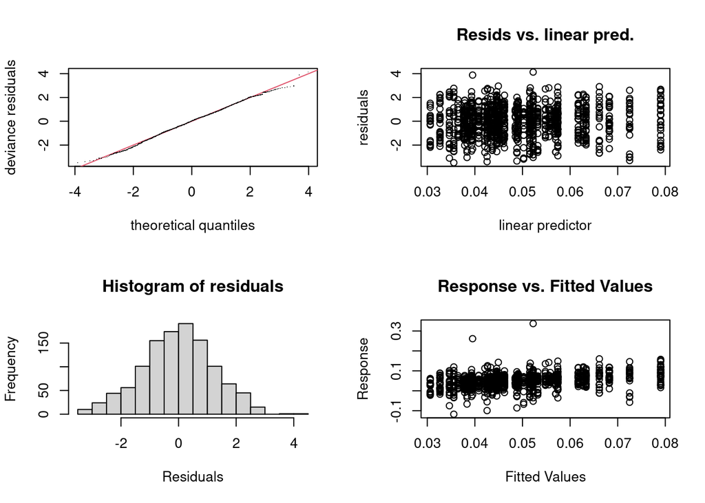

```
##
## Method: fREML   Optimizer: perf chol
## $grad
## [1] 1.28158e-07
##
## $hess
##        [,1]
## [1,] 13.903
##
## Model rank =  49 / 49
##
## Basis dimension (k) checking results. Low p-value (k-index<1) may
## indicate that k is too low, especially if edf is close to k'.
##
##           k'  edf k-index p-value
## s(subj) 47.0 36.9      NA      NA
```

```r
gam.check(m1.scat)
```

## 3.2 Exploratory analysis

Adding cluster as fixed effect:

```r
summary(m2 <- bam(time.lag.norm ~ s(subj,bs='re') + cluster, data=df.nospr, method = "ML"))
```

```
##
## Family: gaussian
## Link function: identity
##
## Formula:
## time.lag.norm ~ s(subj, bs = "re") + cluster
##
## Parametric coefficients:
##              Estimate Std. Error t value Pr(>|t|)
## (Intercept)  0.060982   0.002327  26.209  < 2e-16 ***
## clustersp   -0.014756   0.002079  -7.099 2.26e-12 ***
## clustersx   -0.029271   0.002320 -12.616  < 2e-16 ***
## ---
## Signif. codes:  0 '***' 0.001 '**' 0.01 '*' 0.05 '.' 0.1 ' ' 1
##
## Approximate significance of smooth terms:
##           edf Ref.df    F p-value
## s(subj) 35.99     46 3.97  <2e-16 ***
## ---
## Signif. codes:  0 '***' 0.001 '**' 0.01 '*' 0.05 '.' 0.1 ' ' 1
##
## R-sq.(adj) =  0.226   Deviance explained = 25.2%
## -ML =  -2340  Scale est. = 0.00089993  n = 1138
```

```r
compareML(m,m2)
```

```
## m: time.lag.norm ~ s(subj, bs = "re")
##
## m2: time.lag.norm ~ s(subj, bs = "re") + cluster
```

```
##
## Chi-square test of ML scores
## -----
##   Model     Score Edf Difference    Df  p.value Sig.
## 1     m -2264.913   2
## 2    m2 -2339.997   4     75.084 2.000  < 2e-16  ***
##
## AIC difference: 153.89, model m2 has lower AIC.
```

Improves.

Adding cluster:group as fixed effect:

```r
summary(m3 <- bam(time.lag.norm ~ s(subj,bs='re') + cluster*group, data=df.nospr, method = "ML"))
```

```
##
## Family: gaussian
## Link function: identity
##
## Formula:
## time.lag.norm ~ s(subj, bs = "re") + cluster * group
##
## Parametric coefficients:
##                    Estimate Std. Error t value Pr(>|t|)
## (Intercept)        0.061894   0.003190  19.405  < 2e-16 ***
## clustersp         -0.016587   0.002844  -5.833 7.17e-09 ***
## clustersx         -0.038015   0.003216 -11.819  < 2e-16 ***
## groupPD           -0.002086   0.004632  -0.450 0.652566
## clustersp:groupPD  0.004014   0.004138   0.970 0.332270
## clustersx:groupPD  0.017828   0.004615   3.863 0.000118 ***
## ---
## Signif. codes:  0 '***' 0.001 '**' 0.01 '*' 0.05 '.' 0.1 ' ' 1
##
## Approximate significance of smooth terms:
##           edf Ref.df    F p-value
## s(subj) 35.19     45 4.02  <2e-16 ***
## ---
## Signif. codes:  0 '***' 0.001 '**' 0.01 '*' 0.05 '.' 0.1 ' ' 1
##
## R-sq.(adj) =  0.236   Deviance explained = 26.3%
## -ML = -2348.4  Scale est. = 0.00088853  n = 1138
```

```r
compareML(m2,m3)
```

```
## m2: time.lag.norm ~ s(subj, bs = "re") + cluster
##
## m3: time.lag.norm ~ s(subj, bs = "re") + cluster * group
```

```
##
## Chi-square test of ML scores
## -----
##   Model     Score Edf Difference    Df   p.value Sig.
## 1    m2 -2339.997   4
## 2    m3 -2348.373   7      8.376 3.000 7.947e-04  ***
##
## AIC difference: 12.36, model m3 has lower AIC.
```

Sign. improvement.

Add by-subj random slopes for cluster

```r
summary(m3 <- bam(time.lag.norm ~ s(subj,bs='re') + cluster*group, data=df.nospr, method="REML")) #fit m3 using REML
```

```
##
## Family: gaussian
## Link function: identity
##
## Formula:
## time.lag.norm ~ s(subj, bs = "re") + cluster * group
##
## Parametric coefficients:
##                    Estimate Std. Error t value Pr(>|t|)
## (Intercept)        0.061902   0.003239  19.109  < 2e-16 ***
## clustersp         -0.016591   0.002843  -5.835 7.08e-09 ***
## clustersx         -0.038038   0.003216 -11.827  < 2e-16 ***
## groupPD           -0.002109   0.004703  -0.449 0.653847
## clustersp:groupPD  0.004020   0.004137   0.972 0.331444
## clustersx:groupPD  0.017846   0.004615   3.867 0.000117 ***
## ---
## Signif. codes:  0 '***' 0.001 '**' 0.01 '*' 0.05 '.' 0.1 ' ' 1
##
## Approximate significance of smooth terms:
##           edf Ref.df     F p-value
## s(subj) 35.57     45 4.064  <2e-16 ***
## ---
## Signif. codes:  0 '***' 0.001 '**' 0.01 '*' 0.05 '.' 0.1 ' ' 1
##
## R-sq.(adj) =  0.236   Deviance explained = 26.3%
## -REML = -2318.8  Scale est. = 0.0008882  n = 1138
```

```r
summary(m4 <- bam(time.lag.norm ~ s(subj,bs='re') + s(subj, cluster, bs="re") + cluster*group, data=df.nospr, method="REML"))
```

```
##
## Family: gaussian
## Link function: identity
##
## Formula:
## time.lag.norm ~ s(subj, bs = "re") + s(subj, cluster, bs = "re") +
##     cluster * group
##
## Parametric coefficients:
##                    Estimate Std. Error t value Pr(>|t|)
## (Intercept)        0.061154   0.004879  12.534   <2e-16 ***
## clustersp         -0.015621   0.006467  -2.415   0.0159 *
## clustersx         -0.039058   0.006658  -5.867    6e-09 ***
## groupPD           -0.001024   0.007060  -0.145   0.8847
## clustersp:groupPD  0.002155   0.009319   0.231   0.8172
## clustersx:groupPD  0.016815   0.009705   1.733   0.0835 .
## ---
## Signif. codes:  0 '***' 0.001 '**' 0.01 '*' 0.05 '.' 0.1 ' ' 1
##
## Approximate significance of smooth terms:
##                  edf Ref.df     F p-value
## s(subj)         12.2     45 4.903  0.0806 .
## s(subj,cluster) 98.3    131 6.228  <2e-16 ***
## ---
## Signif. codes:  0 '***' 0.001 '**' 0.01 '*' 0.05 '.' 0.1 ' ' 1
##
## R-sq.(adj) =  0.447   Deviance explained = 50.3%
## -REML = -2410.6  Scale est. = 0.0006433  n = 1138
```

```r
compareML(m3, m4)
```

```
## m3: time.lag.norm ~ s(subj, bs = "re") + cluster * group
##
## m4: time.lag.norm ~ s(subj, bs = "re") + s(subj, cluster, bs = "re") +
##     cluster * group
```

```
##
## Chi-square test of REML scores
## -----
##   Model     Score Edf Difference    Df  p.value Sig.
## 1    m3 -2318.785   7
## 2    m4 -2410.614   8     91.830 1.000  < 2e-16  ***
##
## AIC difference: 292.47, model m4 has lower AIC.
```

We need the random slope.

Let’s start over with the new random effects structure:

```r
m4minusGroup <- bam(time.lag.norm ~ s(subj,bs='re') + s(subj, cluster, bs="re") + cluster, data=df.nospr, method = "ML") #fit using ML
m4withGroup <- bam(time.lag.norm ~ s(subj,bs='re') + s(subj, cluster, bs="re") + cluster*group, data=df.nospr, method = "ML") #fit using ML
compareML(m4minusGroup, m4withGroup)
```

```
## m4minusGroup: time.lag.norm ~ s(subj, bs = "re") + s(subj, cluster, bs = "re") +
##     cluster
##
## m4withGroup: time.lag.norm ~ s(subj, bs = "re") + s(subj, cluster, bs = "re") +
##     cluster * group
```

```
##
## Chi-square test of ML scores
## -----
##          Model     Score Edf Difference    Df p.value Sig.
## 1 m4minusGroup -2434.563   5
## 2  m4withGroup -2436.931   8      2.368 3.000   0.192
##
## AIC difference: 0.19, model m4withGroup has lower AIC.
```

We don’t need group.

Gender

```r
summary(m6 <- bam(time.lag.norm ~ s(subj,bs='re') + s(subj, cluster, bs="re") + cluster + gender, data=df.nospr, method = "ML"))
```

```
##
## Family: gaussian
## Link function: identity
##
## Formula:
## time.lag.norm ~ s(subj, bs = "re") + s(subj, cluster, bs = "re") +
##     cluster + gender
##
## Parametric coefficients:
##              Estimate Std. Error t value Pr(>|t|)
## (Intercept)  0.058558   0.003692  15.860  < 2e-16 ***
## clustersp   -0.014546   0.004621  -3.148  0.00169 **
## clustersx   -0.031184   0.004807  -6.487 1.36e-10 ***
## genderF      0.008065   0.004986   1.617  0.10608
## ---
## Signif. codes:  0 '***' 0.001 '**' 0.01 '*' 0.05 '.' 0.1 ' ' 1
##
## Approximate significance of smooth terms:
##                     edf Ref.df     F p-value
## s(subj)           9.998     45 3.115   0.116
## s(subj,cluster) 101.463    133 5.963  <2e-16 ***
## ---
## Signif. codes:  0 '***' 0.001 '**' 0.01 '*' 0.05 '.' 0.1 ' ' 1
##
## R-sq.(adj) =  0.446   Deviance explained = 50.1%
## -ML = -2435.8  Scale est. = 0.00064445  n = 1138
```

```r
compareML(m4minusGroup, m6)
```

```
## m4minusGroup: time.lag.norm ~ s(subj, bs = "re") + s(subj, cluster, bs = "re") +
##     cluster
##
## m6: time.lag.norm ~ s(subj, bs = "re") + s(subj, cluster, bs = "re") +
##     cluster + gender
```

```
##
## Chi-square test of ML scores
## -----
##          Model     Score Edf Difference    Df p.value Sig.
## 1 m4minusGroup -2434.563   5
## 2           m6 -2435.835   6      1.273 1.000   0.111
##
## AIC difference: -2.38, model m4minusGroup has lower AIC.
```

No need for gender.

Add recording.no

```r
summary(m7 <- bam(time.lag.norm ~ s(subj,bs='re') + s(subj, cluster, bs="re") + cluster + s(recording.no), data=df.nospr, method = "ML"))
```

```
##
## Family: gaussian
## Link function: identity
##
## Formula:
## time.lag.norm ~ s(subj, bs = "re") + s(subj, cluster, bs = "re") +
##     cluster + s(recording.no)
##
## Parametric coefficients:
##              Estimate Std. Error t value Pr(>|t|)
## (Intercept)  0.060716   0.003495  17.373  < 2e-16 ***
## clustersp   -0.014598   0.004629  -3.154  0.00166 **
## clustersx   -0.031258   0.004816  -6.490 1.34e-10 ***
## ---
## Signif. codes:  0 '***' 0.001 '**' 0.01 '*' 0.05 '.' 0.1 ' ' 1
##
## Approximate significance of smooth terms:
##                     edf  Ref.df     F p-value
## s(subj)          11.973  46.000 4.467  0.0737 .
## s(subj,cluster) 100.741 134.000 6.222  <2e-16 ***
## s(recording.no)   1.001   1.001 1.793  0.1810
## ---
## Signif. codes:  0 '***' 0.001 '**' 0.01 '*' 0.05 '.' 0.1 ' ' 1
##
## R-sq.(adj) =  0.446   Deviance explained = 50.3%
## -ML = -2435.5  Scale est. = 0.00064374  n = 1138
```

```r
compareML(m4minusGroup, m7, suggest.report=T)
```

```
## m4minusGroup: time.lag.norm ~ s(subj, bs = "re") + s(subj, cluster, bs = "re") +
##     cluster
##
## m7: time.lag.norm ~ s(subj, bs = "re") + s(subj, cluster, bs = "re") +
##     cluster + s(recording.no)
```

```
##
## Report suggestion: The Chi-Square test on the ML scores indicates that model m7 is [not significantly] better than model m4minusGroup (X2(2.00)=0.896, p>.1).
## -----
##          Model     Score Edf Difference    Df p.value Sig.
## 1 m4minusGroup -2434.563   5
## 2           m7 -2435.459   7      0.896 2.000   0.408
##
## AIC difference: -0.11, model m4minusGroup has lower AIC.
```

No improvement.

Add age.

```r
summary(m8 <- bam(time.lag.norm ~ s(subj,bs='re') + s(subj, cluster, bs="re") + cluster  + s(age), data=df.nospr, method = "ML"))
```

```
##
## Family: gaussian
## Link function: identity
##
## Formula:
## time.lag.norm ~ s(subj, bs = "re") + s(subj, cluster, bs = "re") +
##     cluster + s(age)
##
## Parametric coefficients:
##              Estimate Std. Error t value Pr(>|t|)
## (Intercept)  0.060556   0.003430  17.657  < 2e-16 ***
## clustersp   -0.014612   0.004632  -3.155  0.00165 **
## clustersx   -0.031209   0.004817  -6.478 1.44e-10 ***
## ---
## Signif. codes:  0 '***' 0.001 '**' 0.01 '*' 0.05 '.' 0.1 ' ' 1
##
## Approximate significance of smooth terms:
##                     edf  Ref.df     F p-value
## s(subj)           8.388  45.000 2.223  0.1284
## s(subj,cluster) 102.912 133.000 5.916  <2e-16 ***
## s(age)            1.001   1.001 4.919  0.0267 *
## ---
## Signif. codes:  0 '***' 0.001 '**' 0.01 '*' 0.05 '.' 0.1 ' ' 1
##
## R-sq.(adj) =  0.446   Deviance explained = 50.2%
## -ML = -2436.9  Scale est. = 0.00064402  n = 1138
```

```r
compareML(m4minusGroup, m8)
```

```
## m4minusGroup: time.lag.norm ~ s(subj, bs = "re") + s(subj, cluster, bs = "re") +
##     cluster
##
## m8: time.lag.norm ~ s(subj, bs = "re") + s(subj, cluster, bs = "re") +
##     cluster + s(age)
```

```
##
## Chi-square test of ML scores
## -----
##          Model     Score Edf Difference    Df p.value Sig.
## 1 m4minusGroup -2434.563   5
## 2           m8 -2436.913   7      2.350 2.000   0.095
##
## AIC difference: -4.52, model m4minusGroup has lower AIC.
```

No improvement.

Add dialect.

```r
summary(m9 <- bam(time.lag.norm ~ s(subj,bs='re') + s(subj, cluster, bs="re") + cluster + dialect, data=df.nospr, method = "ML"))
```

```
##
## Family: gaussian
## Link function: identity
##
## Formula:
## time.lag.norm ~ s(subj, bs = "re") + s(subj, cluster, bs = "re") +
##     cluster + dialect
##
## Parametric coefficients:
##                       Estimate Std. Error t value Pr(>|t|)
## (Intercept)           0.060561   0.003947  15.343  < 2e-16 ***
## clustersp            -0.014578   0.004626  -3.151  0.00167 **
## clustersx            -0.031209   0.004814  -6.484 1.39e-10 ***
## dialectFrisian        0.005498   0.008140   0.675  0.49954
## dialectNedersaksisch -0.001128   0.004904  -0.230  0.81819
## ---
## Signif. codes:  0 '***' 0.001 '**' 0.01 '*' 0.05 '.' 0.1 ' ' 1
##
## Approximate significance of smooth terms:
##                   edf Ref.df     F p-value
## s(subj)         11.10     44 4.333   0.057 .
## s(subj,cluster) 99.77    132 6.256  <2e-16 ***
## ---
## Signif. codes:  0 '***' 0.001 '**' 0.01 '*' 0.05 '.' 0.1 ' ' 1
##
## R-sq.(adj) =  0.446   Deviance explained = 50.2%
## -ML = -2434.9  Scale est. = 0.0006444  n = 1138
```

```r
compareML(m4minusGroup, m9)
```

```
## m4minusGroup: time.lag.norm ~ s(subj, bs = "re") + s(subj, cluster, bs = "re") +
##     cluster
##
## m9: time.lag.norm ~ s(subj, bs = "re") + s(subj, cluster, bs = "re") +
##     cluster + dialect
```

```
##
## Chi-square test of ML scores
## -----
##          Model     Score Edf Difference    Df p.value Sig.
## 1 m4minusGroup -2434.563   5
## 2           m9 -2434.862   7      0.299 2.000   0.741
##
## AIC difference: -0.81, model m4minusGroup has lower AIC.
```

No improvement.

Try to add group once more:

```r
summary(m10 <- bam(time.lag.norm ~ s(subj,bs='re') + s(subj, cluster, bs="re") + cluster + group, data=df.nospr, method = "ML"))
```

```
##
## Family: gaussian
## Link function: identity
##
## Formula:
## time.lag.norm ~ s(subj, bs = "re") + s(subj, cluster, bs = "re") +
##     cluster + group
##
## Parametric coefficients:
##              Estimate Std. Error t value Pr(>|t|)
## (Intercept)  0.058368   0.004076  14.321  < 2e-16 ***
## clustersp   -0.014627   0.004628  -3.160  0.00162 **
## clustersx   -0.031135   0.004815  -6.466 1.56e-10 ***
## groupPD      0.004817   0.004449   1.083  0.27921
## ---
## Signif. codes:  0 '***' 0.001 '**' 0.01 '*' 0.05 '.' 0.1 ' ' 1
##
## Approximate significance of smooth terms:
##                    edf Ref.df     F p-value
## s(subj)          10.85     45 3.838  0.0783 .
## s(subj,cluster) 100.83    133 6.150  <2e-16 ***
## ---
## Signif. codes:  0 '***' 0.001 '**' 0.01 '*' 0.05 '.' 0.1 ' ' 1
##
## R-sq.(adj) =  0.446   Deviance explained = 50.2%
## -ML = -2435.1  Scale est. = 0.00064432  n = 1138
```

```r
compareML(m4minusGroup, m10)
```

```
## m4minusGroup: time.lag.norm ~ s(subj, bs = "re") + s(subj, cluster, bs = "re") +
##     cluster
##
## m10: time.lag.norm ~ s(subj, bs = "re") + s(subj, cluster, bs = "re") +
##     cluster + group
```

```
##
## Chi-square test of ML scores
## -----
##          Model     Score Edf Difference    Df p.value Sig.
## 1 m4minusGroup -2434.563   5
## 2          m10 -2435.140   6      0.577 1.000   0.283
##
## AIC difference: -1.17, model m4minusGroup has lower AIC.
```

No improvement.

Try to add group*cluster interaction once more:

```r
summary(m11 <- bam(time.lag.norm ~ s(subj,bs='re') + s(subj, cluster, bs="re") + cluster*group, data=df.nospr, method = "ML"))
```

```
##
## Family: gaussian
## Link function: identity
##
## Formula:
## time.lag.norm ~ s(subj, bs = "re") + s(subj, cluster, bs = "re") +
##     cluster * group
##
## Parametric coefficients:
##                    Estimate Std. Error t value Pr(>|t|)
## (Intercept)        0.061161   0.004755  12.861  < 2e-16 ***
## clustersp         -0.015632   0.006302  -2.480   0.0133 *
## clustersx         -0.038992   0.006496  -6.003 2.69e-09 ***
## groupPD           -0.001030   0.006882  -0.150   0.8811
## clustersp:groupPD  0.002182   0.009081   0.240   0.8101
## clustersx:groupPD  0.016769   0.009466   1.771   0.0768 .
## ---
## Signif. codes:  0 '***' 0.001 '**' 0.01 '*' 0.05 '.' 0.1 ' ' 1
##
## Approximate significance of smooth terms:
##                   edf Ref.df     F p-value
## s(subj)         12.21     45 4.653  0.0523 .
## s(subj,cluster) 97.25    131 6.023  <2e-16 ***
## ---
## Signif. codes:  0 '***' 0.001 '**' 0.01 '*' 0.05 '.' 0.1 ' ' 1
##
## R-sq.(adj) =  0.446   Deviance explained = 50.1%
## -ML = -2436.9  Scale est. = 0.00064443  n = 1138
```

```r
compareML(m4minusGroup, m11)
```

```
## m4minusGroup: time.lag.norm ~ s(subj, bs = "re") + s(subj, cluster, bs = "re") +
##     cluster
##
## m11: time.lag.norm ~ s(subj, bs = "re") + s(subj, cluster, bs = "re") +
##     cluster * group
```

```
##
## Chi-square test of ML scores
## -----
##          Model     Score Edf Difference    Df p.value Sig.
## 1 m4minusGroup -2434.563   5
## 2          m11 -2436.931   8      2.368 3.000   0.192
##
## AIC difference: 0.19, model m11 has lower AIC.
```

Fit final model:

```r
summary(m5REML <- bam(time.lag.norm ~ s(subj,bs='re') + s(subj, cluster, bs="re") + cluster, data=df.nospr, method = "REML"))
```

```
##
## Family: gaussian
## Link function: identity
##
## Formula:
## time.lag.norm ~ s(subj, bs = "re") + s(subj, cluster, bs = "re") +
##     cluster
##
## Parametric coefficients:
##              Estimate Std. Error t value Pr(>|t|)
## (Intercept)  0.060667   0.003538  17.147  < 2e-16 ***
## clustersp   -0.014586   0.004682  -3.115  0.00189 **
## clustersx   -0.031219   0.004870  -6.410 2.21e-10 ***
## ---
## Signif. codes:  0 '***' 0.001 '**' 0.01 '*' 0.05 '.' 0.1 ' ' 1
##
## Approximate significance of smooth terms:
##                    edf Ref.df     F p-value
## s(subj)          12.11     46 4.702  0.0847 .
## s(subj,cluster) 101.08    134 6.324  <2e-16 ***
## ---
## Signif. codes:  0 '***' 0.001 '**' 0.01 '*' 0.05 '.' 0.1 ' ' 1
##
## R-sq.(adj) =  0.446   Deviance explained = 50.2%
## -REML = -2420.4  Scale est. = 0.00064372  n = 1138
```